# Cartographie statique avec mapsf

### Carte choroplèthe habillée

On peut arriver à une carte beaucoup plus satisfaisante en contrôlant l’ensemble des paramètres de couleur et de découpage des classes. Puis en superposant les contours de communes au dessus de la carte des IRIS pour faciliter le repérage.

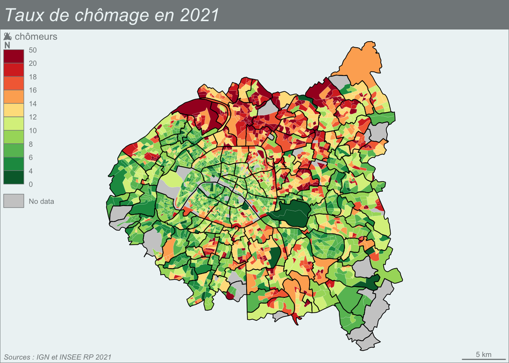

```r
# Choisir les classes et la palette
mybreaks = c(0, 4, 6, 8, 10, 12, 14, 16, 18,20,50)

# Tracer la carte choroplèthe
mf_map( map_iris, var = "TxCHO",type = "choro",
  breaks = mybreaks,pal = mypal,
  border="white",
  lwd=0.1,
  col_na = "gray80",
 leg_title = "% chômeurs",
 leg_val_rnd = 0)
# Ajouter les contours des communes
mf_map(map_com, type = "base", col = NA,
       border="black",lwd=1,add = TRUE)
# Ajouter un cadre, un titre et des sources
mf_layout(title = "Taux de chômage en 2021",
          frame = TRUE,
          credits = "Sources : IGN et INSEE RP 2021")
```

## Carte stock + choroplèthe

Mais on peut aussi utiliser le type `prop_choro`

```r
mf_theme("agolalight")
mybreaks = c(0, 4, 6, 8, 10, 12, 14, 16, 18,20,50)

mf_map(map_iris, type = "base",
       col = "gray80",border="white", lwd=0.3)
mf_map(map_com, type = "base",
       col = NA,border="white",lwd=1,add = TRUE)
mf_prop_choro( x = map_iris,  var = c("ACT", "TxCHO"),
  inches = 0.08, col_na = "grey", pal=mypal,
  breaks = mybreaks, nbreaks = 4, lwd = 0.1,
  leg_pos = c("right", "left"),leg_val_rnd = c(0,0),
  leg_title = c("nb. actifs", "% chômeurs"),
  add = TRUE)
```

```
100 'NA' values are not plotted on the map.
```

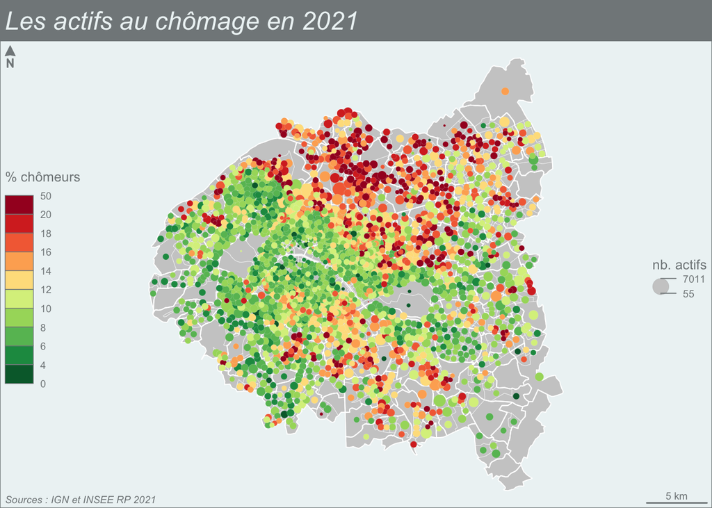

```r
mf_layout(title = "Les actifs au chômage en 2021",
        frame = TRUE, credits = "Sources : IGN et INSEE RP 2021")
```

## Typologie

On se propose d’examiner le cas d’une variable qualitative résultant d’une classification ascendante hiérarchique. On travaille cette fois-ci à l’échelle des communes

### Extraction du tableau de contingence

On élimine la géométrie et on extrait le tableau de contingence des actifs :

```r
# Extrait les colonnes utiles
tab<-map_com %>% st_drop_geometry() %>% select(com_code, CHO, DIV, EMP, ETU, RET) %>% filter(is.na(CHO)==F)


# Transforme en matrice de % en ligne
mat<-as.matrix(tab[,-1])
rownames(mat)<-tab$com_code

matpct<-100*prop.table(mat,1)
```

### Calcul de l’ACP et de la CAH

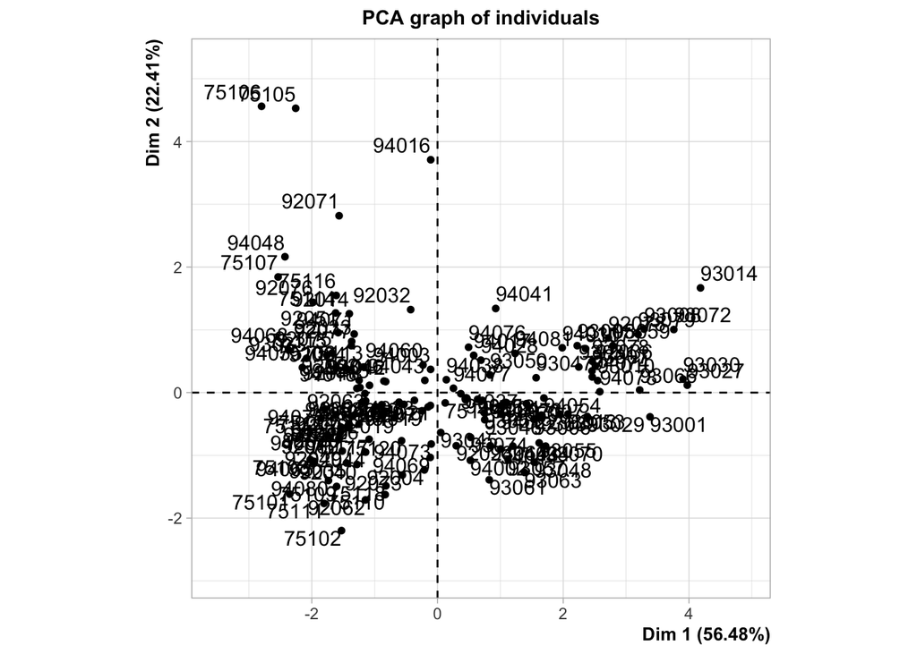

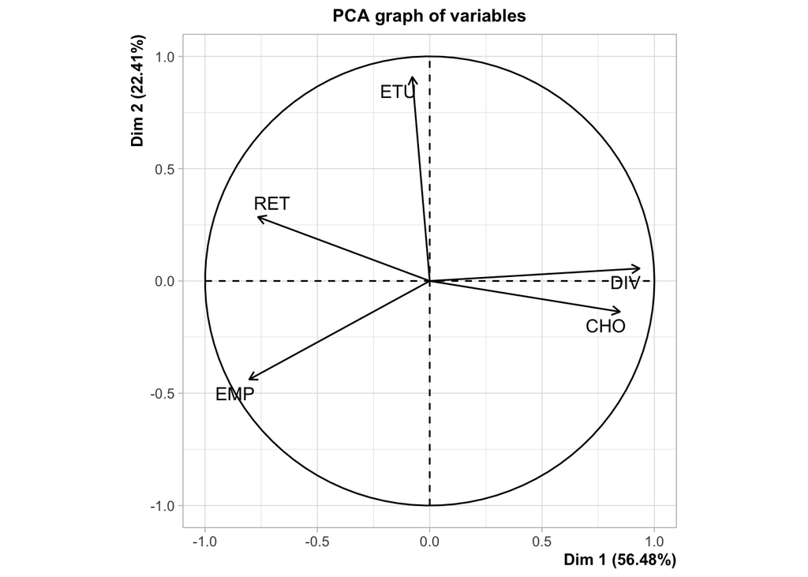

```r
# Calcule l'AFC puis la CAH
library(FactoMineR)
acp<-PCA(matpct)
```

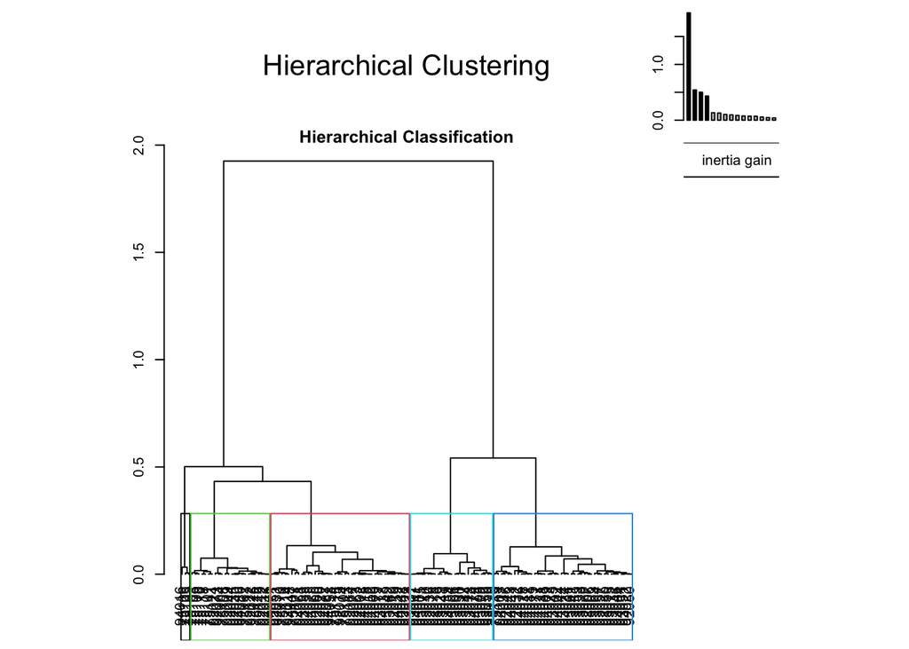

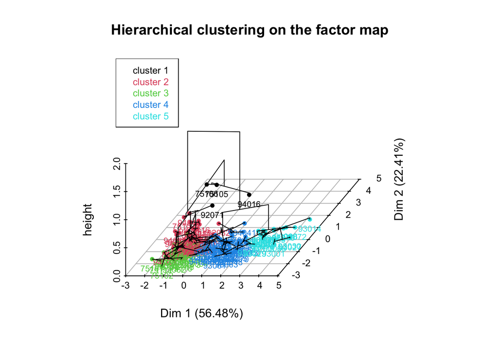

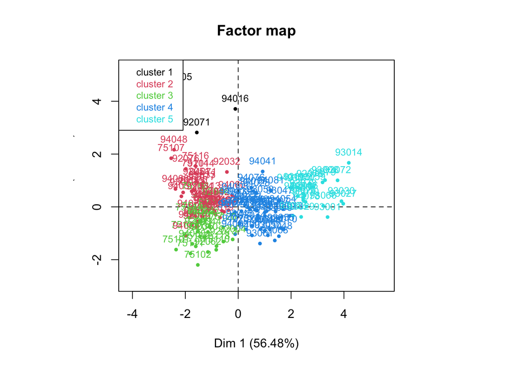

```r
cah<-HCPC(acp,nb.clust =5)
```

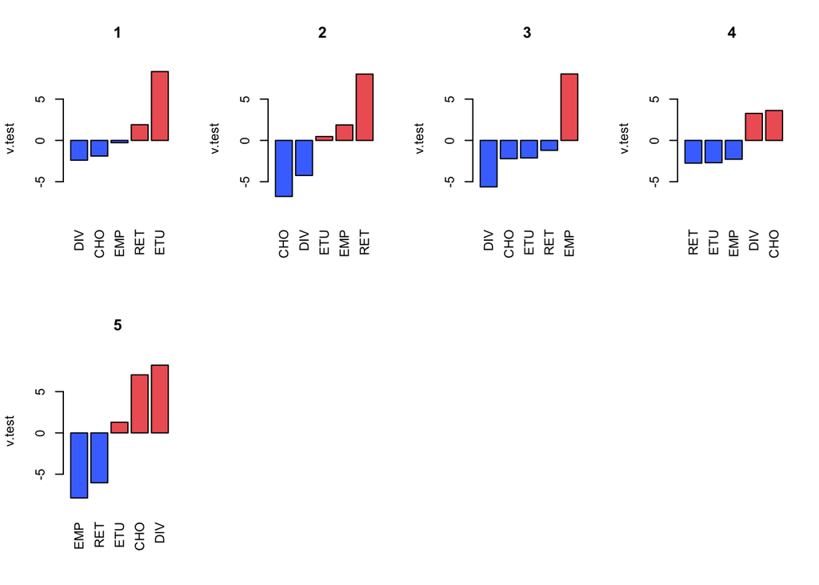

```r
# Récupère les résultats
tab$typo <- cah$data.clust$clust

# analyse les profils
tabres<-cah$data.clust
plot.catdes(catdes(tabres,6,proba = 1),level = 1,barplot = T)
```

### Cartographie des résultats

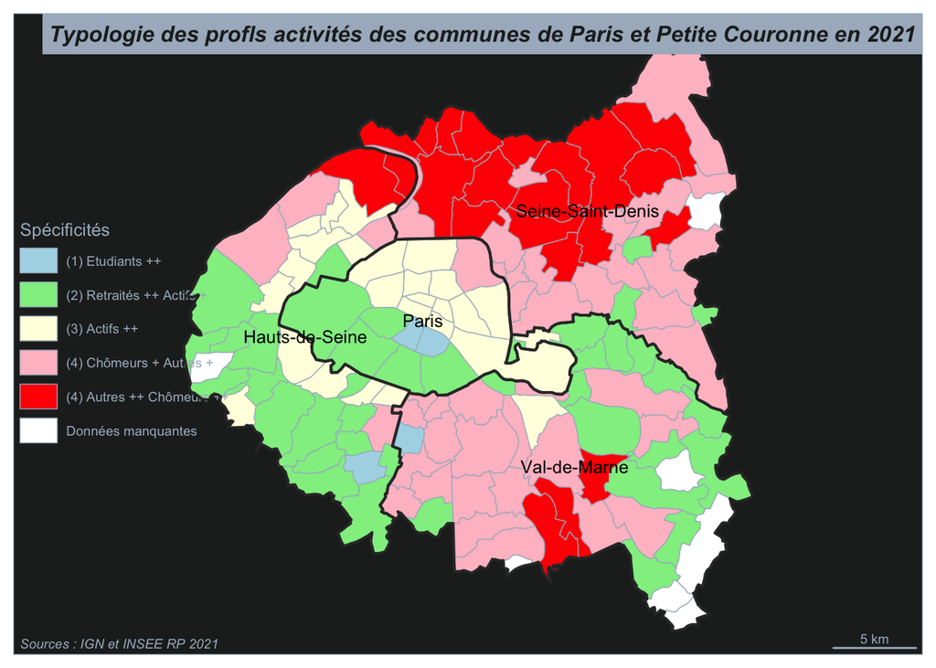

```r
# Ajoute la typo au fonds de carte
map_com_typo <-map_com %>% select(com_code,com_name, geometry) %>%
                                left_join(tab)
# Transforme la typo en facteur
map_com_typo$typoqual<-as.factor(map_com_typo$typo)
levels(map_com_typo$typoqual) <- c("(1) Etudiants ++",
                                   "(2) Retraités ++ Actifs +",
                                   "(3) Actifs ++",
                                   "(4) Chômeurs + Autres +",
                                   "(4) Autres ++ Chômeurs ++")

# Carte de typologie
mf_theme("darkula")
mf_map(map_com_typo,
       type = "typo",
       var = "typoqual",
       pal= c("lightblue","lightgreen","lightyellow","pink","red"),
       leg_title = "Spécificités",
       col_na = "white",
       leg_pos = "left",
       leg_no_data = "Données manquantes")
# Ajoute les contours des départements
mf_map(map_dep,  type = "base",
       col = NA,lwd=2,
       add = TRUE)
# Ajoute les noms des départements
mf_label(map_dep,
         var="dep_name",
         cex=0.8,
         col="black",
         overlap = FALSE)

mf_layout(title = "Typologie des profls activités des communes de Paris et Petite Couronne en 2021",
        frame = TRUE, credits = "Sources : IGN et INSEE RP 2021",
        arrow = F
        )
```